# Prosper Loan Data Exploration

## Preliminary Wrangling

```python
# import all packages and set plots to be embedded inline
import numpy as np
import pandas as pd
import matplotlib.pyplot as plt
import matplotlib
import seaborn as sb
%matplotlib inline
```

```python
#load data
raw_data = pd.read_csv('loan_dataset.csv')
```

```python
raw_data.head(3)
```

|  | ListingKey | ListingNumber | ListingCreationDate | CreditGrade | Term | LoanStatus | ClosedDate | BorrowerAPR | BorrowerRate | LenderYield | ... | LP_ServiceFees | LP_CollectionFees | LP_GrossPrincipalLoss | LP_NetPrincipalLoss | LP_NonPrincipalRecoverypayments | PercentFunded | Recommendations | InvestmentFromFriendsCount | InvestmentFromFriendsAmount | Investors |
| --- | --- | --- | --- | --- | --- | --- | --- | --- | --- | --- | --- | --- | --- | --- | --- | --- | --- | --- | --- | --- | --- |
| 0 | 1021339766868145413AB3B | 193129 | 2007-08-26 19:09:29.263000000 | C | 36 | Completed | 2009-08-14 00:00:00 | 0.16516 | 0.158 | 0.138 | ... | -133.18 | 0.0 | 0.0 | 0.0 | 0.0 | 1.0 | 0 | 0 | 0.0 | 258 |
| 1 | 10273602499503308B223C1 | 1209647 | 2014-02-27 08:28:07.900000000 | NaN | 36 | Current | NaN | 0.12016 | 0.092 | 0.082 | ... | 0.00 | 0.0 | 0.0 | 0.0 | 0.0 | 1.0 | 0 | 0 | 0.0 | 1 |
| 2 | 0EE9337825851032864889A | 81716 | 2007-01-05 15:00:47.090000000 | HR | 36 | Completed | 2009-12-17 00:00:00 | 0.28269 | 0.275 | 0.240 | ... | -24.20 | 0.0 | 0.0 | 0.0 | 0.0 | 1.0 | 0 | 0 | 0.0 | 41 |

3 rows × 81 columns

```python
raw_data.info()
```

```
<class 'pandas.core.frame.DataFrame'>
RangeIndex: 113937 entries, 0 to 113936
Data columns (total 81 columns):
 #   Column                               Non-Null Count   Dtype
---  ------                               --------------   -----
 0   ListingKey                           113937 non-null  object
 1   ListingNumber                        113937 non-null  int64
 2   ListingCreationDate                  113937 non-null  object
 3   CreditGrade                          28953 non-null   object
 4   Term                                 113937 non-null  int64
 5   LoanStatus                           113937 non-null  object
 6   ClosedDate                           55089 non-null   object
 7   BorrowerAPR                          113912 non-null  float64
 8   BorrowerRate                         113937 non-null  float64
 9   LenderYield                          113937 non-null  float64
```

[output cut: 73 more lines]

### Structure of Dataset

> Dataset consist of **113,937** entries on loans borrowed through 'Prosper' peer-to-peer lending marketplace. Each entry (row) has **81** features (fields/columns) that describe certain attributes of the Borrower (Member), borrower's loan request(Listing), Lender(Investor), and the Loan itself.

### Main Feature(s) of Interest in Dataset

> Area of interest is the makeup of Prosper customers (Borrowers)in terms of the level of their income (income range and monthly income), available credit and credit grade.  
> Moreover, categories in which the members apply for loans (business, home improvement,...), size of the loan they usually borrow for the stated purpose and what repayment schedule they desire most ( 12,36 or 60 months) will be explored.  
> Finally, the exploration and analysis are to explain the relationship between certain features of members (monthly income, available credit, debt to income ratio) and Annual Percentage Rate(APR) they recieve.

### Dataset Features Believed to Support Investigation into Feature(s) of Interest

> Following features will be explored. However, if not a good fit for the purpose of this analysis, they might be discarded in later steps.
- **Borrower:**
  - Member Key
  - Occupation
  - Income Range
  - Stated Monthly Income
  - Debt to Income Ratio
  - Available Bankcard Credit
  - Credit Grade
- **Loan:**
  - Listing Key
  - Listing Category
  - Loan Number
  - Loan Original Amount
  - Total Prosper Loans
  - Term
  - Monthly Loan Payment
- **Borrowers Evaluation:**
  - Prosper Rating
  - Borrower APR

```python
clean_data = raw_data[['MemberKey','ListingKey','LoanNumber','Occupation', 'IncomeRange','StatedMonthlyIncome','DebtToIncomeRatio',
                      'AvailableBankcardCredit','CreditGrade', 'ListingCategory (numeric)', 'LoanNumber', 'LoanOriginalAmount', 'Term','BorrowerAPR']]
```

```python
clean_data.duplicated().sum()
```

```
871
```

```python
clean_data = clean_data.drop_duplicates().copy()
clean_data.isna().sum()
```

```
MemberKey                        0
ListingKey                       0
LoanNumber                       0
Occupation                    3529
IncomeRange                      0
StatedMonthlyIncome              0
DebtToIncomeRatio             8472
AvailableBankcardCredit       7544
CreditGrade                  84113
ListingCategory (numeric)        0
LoanNumber                       0
LoanOriginalAmount               0
Term                             0
BorrowerAPR                     25
dtype: int64
```

> **Number of NaN** values in entries for a number of features is significant. Any investigation and analysis on those features will be approached with cautioun.

## Univariate Exploration

In this section data in explored to see how the features of interest are distributed. Special attention will be paid to general makeup of dataset (majority groups), distibutions, trends and existance of outliers.

### Borrowers Profile

`Occupation`, `IncomeRange`,`StatedMonthlyIncome`, `AvailableBankcardCredit`, `CreditGrade`, `DebtToIncomRatio`

#### Occupation

```python
clean_data.Occupation.isna().sum()
```

```
3529
```

```python
clean_data.Occupation.value_counts()
```

```
Other                          28422
Professional                   13531
Computer Programmer             4442
Executive                       4280
Teacher                         3729
                               ...
Dentist                           67
Student - College Freshman        41
Student - Community College       28
Judge                             22
Student - Technical School        16
Name: Occupation, Length: 67, dtype: int64
```

```python
clean_data.Occupation.value_counts().describe()
```

```
count       67.000000
mean      1634.880597
std       3848.307009
min         16.000000
25%        191.000000
50%        488.000000
75%       1569.500000
max      28422.000000
Name: Occupation, dtype: float64
```

```python
np.log10(clean_data.Occupation.value_counts()).describe()
```

```
count    67.000000
mean      2.720285
std       0.661333
min       1.204120
25%       2.280938
50%       2.688420
75%       3.195755
max       4.453655
Name: Occupation, dtype: float64
```

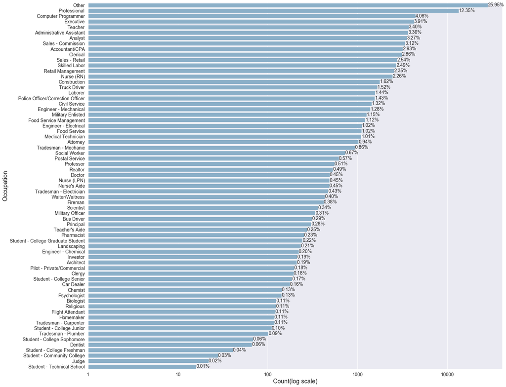

```python
plt.figure(figsize = (22,20))
base_color = sb.color_palette()[4]

plt.style.context('fivethirtyeight')

occupation_order = clean_data.Occupation.value_counts().index
sb.countplot(data = clean_data, y = 'Occupation', order = occupation_order, color = base_color)

occupation_xticks_loc = [1,10,100,1000,10000]
plt.xscale('log')
plt.xticks(occupation_xticks_loc,occupation_xticks_loc, size = 14)
plt.xlabel('Count(log scale)', size = 18)
plt.yticks(size = 14)

occupation_count = clean_data.Occupation.value_counts()
ytick_loc, ytick_label = plt.yticks()
all_occupation_count = clean_data.Occupation.shape[0] - clean_data.Occupation.isna().sum()
for yt_loc, yt_lab in zip(ytick_loc, ytick_label):
    count_onx = occupation_count[yt_lab.get_text()]
    plt.text(count_onx,yt_loc, '{:.2f}%'.format(100*count_onx/all_occupation_count), va = 'center', size = 14);
```

> Out of **113066** entries, **3529** for **`Occupation`** are **NaN** values. And in **40%** of the entries, it is not clear what the occupation is as the value is either 'Other' or 'Professional'. Therefore, `Occupation`will not be used to categorize members.

## Income Range

```python
clean_data.IncomeRange.isna().sum()
```

```
0
```

```python
income_categories = ['$0', '$1-24,999','$25,000-49,999','$50,000-74,999','$75,000-99,999', '$100,000+','Not employed', 'Not displayed']
income_type = pd.api.types.CategoricalDtype(ordered = True, categories = income_categories)
clean_data.IncomeRange = clean_data.IncomeRange.astype(income_type)
```

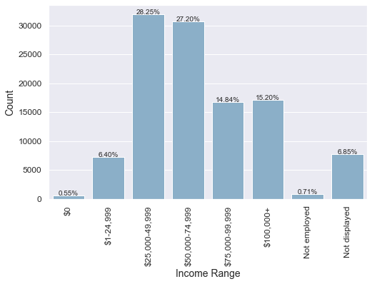

```python
plt.figure(figsize = (8,5))
plt.style.context('fivethirtyeight')

sb.countplot(data = clean_data, x = 'IncomeRange', color = base_color)
plt.xticks(size = 12,rotation = '90')
plt.yticks(size = 12)
plt.xlabel('Income Range' , size = 14)
plt.ylabel('Count' , size = 14)

IncomeRange_count = clean_data.IncomeRange.value_counts()
xtick_loc, xtick_label = plt.xticks()
all_IncomeRange_count = clean_data.IncomeRange.shape[0] - clean_data.IncomeRange.isna().sum()
for xt_loc, xt_lab in zip(xtick_loc, xtick_label):
    count_ony = IncomeRange_count[xt_lab.get_text()]
    plt.text(xt_loc,count_ony, '{:.2f}%'.format(100*count_ony/all_IncomeRange_count), ha = 'center');
```

> At this point, **`IncomeRange`** seems to be an ideal representation of categories of borrowers as there are no NaN values and the categories are informative enough. 'Not Displayed' does not offer much explanation. Since it accounts for only ~7%of the dataset, it will not interfere with my investigation.  
> Given that **85%** of members fall into **4 categories** ( \$25,000-100,000+ Income Range), in bivariant and multi-variantexploration the focus will be solely on these categories. However, it should be first investigated how much of the loans borrowed is attributed to them. It will be clarified later in the section of bivariant explorations.

## Stated Monthly Income

```python
clean_data.StatedMonthlyIncome.isna().sum()
```

```
0
```

```python
clean_data.StatedMonthlyIncome.describe()
```

```
count    1.130660e+05
mean     5.605120e+03
std      7.495596e+03
min      0.000000e+00
25%      3.199396e+03
50%      4.666667e+03
75%      6.824688e+03
max      1.750003e+06
Name: StatedMonthlyIncome, dtype: float64
```

```python
np.log10(clean_data.StatedMonthlyIncome).describe()
```

```
count    1.130660e+05
mean             -inf
std               NaN
min              -inf
25%      3.505068e+00
50%      3.669007e+00
75%      3.834083e+00
max      6.243039e+00
Name: StatedMonthlyIncome, dtype: float64
```

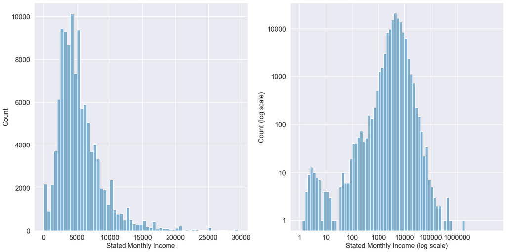

```python
plt.style.context('fivethirtyeight')

fig, (ax1,ax2) = plt.subplots(1,2, figsize = (20,10))

#histogram on left (log scaling)
bin_edges = 10**np.arange(0,6.5+0.99,0.1)
ax2.hist(clean_data.StatedMonthlyIncome, bins = bin_edges,color = base_color)

xticks_loc =[1,10,100,1000,10000,100000,1000000]
ax2.set_xscale('log')
ax2.set_xticks(xticks_loc)
ax2.set_xlabel('Stated Monthly Income (log scale)', size = 16)
ax2.set_xticklabels(xticks_loc)

yticks_loc =[1,10,100,1000,10000,]
ax2.set_yscale('log')
ax2.set_yticks(yticks_loc)
ax2.set_yticklabels(yticks_loc)
ax2.set_ylabel('Count (log scale)', size = 16)


#histogram on right (monthly income under 30,000)
bin_edges = np.arange(0,30000,500)
ax1.hist(clean_data.StatedMonthlyIncome, bins = bin_edges,color = base_color)
ax1.set_xlabel('Stated Monthly Income', size = 16)
ax1.set_ylabel('Count', size = 16);
```

> Data for monthly income is spread over a considerably large range ( 0 – 1.75 million) while 75% of values fell under 7000 . Using the linear scale would show and drastically skewed distribution that would not represent the data accurately. To Solve this problem the data was scaled logarithmically(right) and on left distribution only shows the data for which monthly income alls under 30000.  
> Distribution of monthly income appears to be right skewed with Median at ~\$4500, majority have a monthly income between \\$3000-\$10,000

# Debt to Income Ratio

This value is capped at 10.01 (so any actual debt to income ratio larger than 1000% will be returned as 1001%).

```python
clean_data.DebtToIncomeRatio.isna().sum()
```

```
8472
```

```python
clean_data.DebtToIncomeRatio.dropna().describe()
```

```
count    104594.000000
mean          0.276032
std           0.553738
min           0.000000
25%           0.140000
50%           0.220000
75%           0.320000
max          10.010000
Name: DebtToIncomeRatio, dtype: float64
```

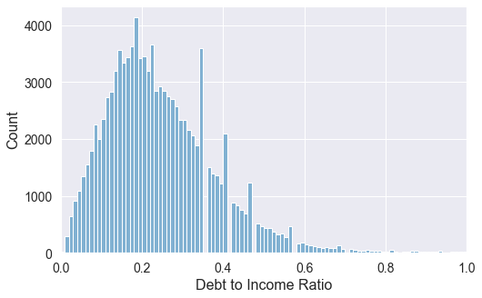

```python
plt.style.context('fivethirtyeight')
plt.figure(figsize = (8,5))

bin_edges = np.arange(0,2,0.01)
plt.hist(clean_data.DebtToIncomeRatio.dropna(),bins = bin_edges, color = base_color)
plt.xlim(0,1)
plt.xlabel('Debt to Income Ratio', size = 16)
plt.ylabel('Count', size = 16)
loc,label = plt.xticks()
plt.xticks(size = 14 )
plt.yticks(size = 14 );
```

> Given the broad range of entries for Debt to Income Ratio (**0%-1000%** with increments as low as 0.1%) **limiting** the selection of data point to those with a maximum ratio of 1.  
> The distribution is right skewed with median at ~0.2 and **75%** of values falling **under ~0.35**.

# Credit Grade

```python
clean_data.CreditGrade.isna().sum()
```

```
84113
```

```python
clean_data.CreditGrade.value_counts()
```

```
C     5649
D     5153
B     4389
AA    3509
HR    3508
A     3315
E     3289
NC     141
Name: CreditGrade, dtype: int64
```

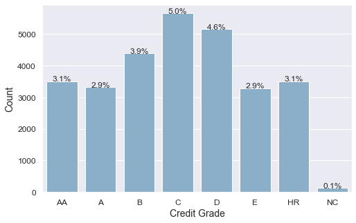

```python
plt.figure(figsize = (8,5))
plt.style.context('fivethirtyeight')
cg_order = ['AA','A','B','C','D','E','HR','NC']
cg_ordered_type = pd.api.types.CategoricalDtype(ordered = True, categories = cg_order)
clean_data.CreditGrade = clean_data.CreditGrade.astype(cg_ordered_type)
sb.countplot(data = clean_data, x ='CreditGrade',color = base_color)
plt.xticks(size = 12)
plt.xlabel('Credit Grade', size = 14)
plt.yticks(size = 12)
plt.ylabel('Count', size = 14)

xtick_loc1 ,xtick_lb1= plt.xticks()
for xt_loc1 ,xt_lb1 in zip(xtick_loc1 ,xtick_lb1):
    CreditGrade_count1 = clean_data.CreditGrade.value_counts()[xt_loc1]
    plt.text(xt_loc1, CreditGrade_count1,'{:.1f}%'.format(100*CreditGrade_count1/clean_data.CreditGrade.shape[0]), size = 12, ha = 'center');
```

# Available Bankcard Credit

```python
clean_data.AvailableBankcardCredit.isna().sum()
```

```
7544
```

```python
clean_data.AvailableBankcardCredit.dropna().describe()
```

```
count    105522.000000
mean      11208.182028
std       19847.681185
min           0.000000
25%         876.000000
50%        4090.000000
75%       13165.000000
max      646285.000000
Name: AvailableBankcardCredit, dtype: float64
```

```python
np.log10(clean_data.AvailableBankcardCredit.dropna()).describe()
```

```
count    1.055220e+05
mean             -inf
std               NaN
min              -inf
25%      2.942504e+00
50%      3.611723e+00
75%      4.119421e+00
max      5.810424e+00
Name: AvailableBankcardCredit, dtype: float64
```

```python
clean_data[clean_data.AvailableBankcardCredit>80000].shape
```

[output not shown]

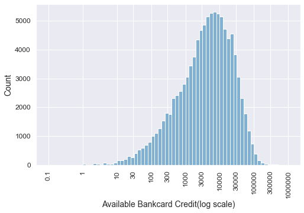

```python
plt.figure(figsize = (8,5))
plt.style.context('fivethirtyeight')
bin_edges = 10 ** np.arange(-1,6+0.1,0.1)
plt.hist(clean_data.AvailableBankcardCredit.dropna(), bins = bin_edges,color = base_color)
xtick_locations = [0.1,1,10,30,100,300,1000,3000,10000,30000,100000,300000,1000000]
plt.xscale('log')
plt.xticks(xtick_locations,xtick_locations, rotation = '90')
plt.xticks(size = 12)
plt.xlabel('Available Bankcard Credit(log scale)', size = 14)
plt.yticks(size = 12)
plt.ylabel('Count', size = 14);
```

> Given the broad range of entries for available credit (between 0 - 600,000+), log scaling proved to be the best way to ensure the distribution is depicted rather accurately.  
> With Median at \$4000, Most members have less than\\$10000 credit available on their bank card and for 20% of member it stand under \$1000. There are outliers on both higher and lower ends and will be dealt with in later stages.

## Listing Category

**The category of the listing that the borrower selected when posting their listing**  
0 - Not Available, 1 - Debt Consolidation, 2 - Home Improvement, 3 - Business, 4 - Personal Loan, 5 - Student Use, 6 - Auto, 7- Other, 8 - Baby&Adoption, 9 - Boat, 10 - Cosmetic Procedure, 11 - Engagement Ring, 12 - Green Loans, 13 - Household Expenses, 14 - Large Purchases, 15 - Medical/Dental, 16 - Motorcycle, 17 - RV, 18 - Taxes, 19 - Vacation, 20 - Wedding Loans

```python
clean_data.rename(columns = {'ListingCategory (numeric)': 'ListingCategory'}, inplace = True)
```

```python
clean_data.ListingCategory.isna().sum()
```

```
0
```

```python
listing_category_dict = {}
listing_category_list = ['Not Available', 'Debt Consolidation', 'Home Improvement', 'Business','Personal Loan', 'Student Use', 'Auto', 'Other', 'Baby&Adoption', 'Boat', 'Cosmetic Procedure', 'Engagement Ring', 'Green Loans', 'Household Expenses', 'Large Purchases', 'Medical/Dental', 'Motorcycle', 'RV', 'Taxes', 'Vacation', 'Wedding Loans']
for n,lc in enumerate(listing_category_list):
    listing_category_dict[n] = lc
listing_category_dict
```

```
{0: 'Not Available',
 1: 'Debt Consolidation',
 2: 'Home Improvement',
 3: 'Business',
 4: 'Personal Loan',
 5: 'Student Use',
 6: 'Auto',
 7: 'Other',
 8: 'Baby&Adoption',
 9: 'Boat',
 10: 'Cosmetic Procedure',
 11: 'Engagement Ring',
 12: 'Green Loans',
 13: 'Household Expenses',
 14: 'Large Purchases',
 15: 'Medical/Dental',
 16: 'Motorcycle',
 17: 'RV',
 18: 'Taxes',
 19: 'Vacation',
 20: 'Wedding Loans'}
```

```python
#replace numeric value with name of the category
for i in range(len(listing_category_dict)):
    rows_to_change = clean_data[clean_data.ListingCategory == i].index
    for j in rows_to_change:
        clean_data.loc[j,'ListingCategory'] = listing_category_dict[i]
```

```python
clean_data.ListingCategory.unique()
```

```
array(['Not Available', 'Home Improvement', 'Motorcycle',
       'Debt Consolidation', 'Other', 'Household Expenses', 'Auto',
       'Medical/Dental', 'Wedding Loans', 'Vacation', 'Business', 'Taxes',
       'Baby&Adoption', 'Personal Loan', 'Engagement Ring',
       'Large Purchases', 'Student Use', 'Boat', 'RV',
       'Cosmetic Procedure', 'Green Loans'], dtype=object)
```

```python
clean_data.to_csv('loans_clean.csv',index = False)
clean_data = pd.read_csv('loans_clean.csv')
```

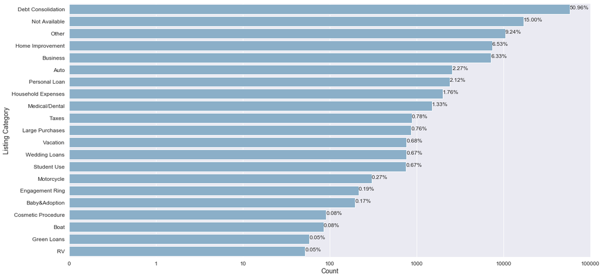

```python
plt.figure(figsize = (20,10))
plt.style.context('fivethirtyeight')

category_order = clean_data.ListingCategory.value_counts().index
sb.countplot(data = clean_data, y = "ListingCategory" , order = category_order, color = base_color);
xticks_loc = 10**np.arange(-1,5+0.1,1)
xticks_labels = ['{}'.format(int(t)) for t in xticks_loc]
plt.xscale('log')
plt.xticks(xticks_loc,xticks_labels, size = 12)
plt.xlabel('Count', Size = 14)

plt.yticks( size = 12)
plt.ylabel('Listing Category', Size = 14)

ytick_loc1 ,ytick_lb1= plt.yticks()
for yt_loc1 ,yt_lb1 in zip(ytick_loc1 ,ytick_lb1):
    category_count1 = clean_data.ListingCategory.value_counts()[yt_lb1.get_text()]
    plt.text(category_count1,yt_loc1, '{:.2f}%'.format(100*category_count1/clean_data.ListingCategory.shape[0]), size = 12)
```

> **51%** of loans are taken for **Debt Consolidation**. Unfortunately 25% of entries offer un-informative data stating 'Not Available' and 'Other' for Listing Category. It should be decided later on how to handle this issue.

# Loan Original Amount

```python
clean_data.LoanOriginalAmount.isna().sum()
```

```
0
```

```python
clean_data.LoanOriginalAmount.describe()
```

```
count    113066.000000
mean       8314.762307
std        6237.007841
min        1000.000000
25%        4000.000000
50%        6300.000000
75%       12000.000000
max       35000.000000
Name: LoanOriginalAmount, dtype: float64
```

```python
np.log10(clean_data.LoanOriginalAmount).describe()
```

```
count    113066.000000
mean          3.793815
std           0.345710
min           3.000000
25%           3.602060
50%           3.799341
75%           4.079181
max           4.544068
Name: LoanOriginalAmount, dtype: float64
```

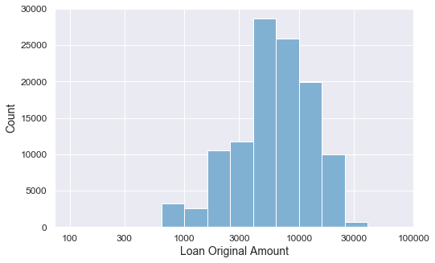

```python
plt.figure(figsize = (8,5))
plt.style.context('fivethirtyeight')

bin_edges2 = 10 ** np.arange(2,4.5+0.2,0.2)
plt.hist(clean_data.LoanOriginalAmount, bins = bin_edges2,color = base_color)

ticks_loc = [100,300,1000,3000,10000,30000,100000]
ticks_label = ['{}'.format(t) for t in ticks_loc]
plt.xscale('log')
plt.xticks(ticks_loc,ticks_label, size = 12)
plt.xlabel('Loan Original Amount', Size = 14)

plt.yticks( size = 12)
plt.ylabel('Count', Size = 14);
```

# Term

```python
clean_data.Term.isna().sum()
```

```
0
```

```python
clean_data.Term.unique()
```

```
array([36, 60, 12])
```

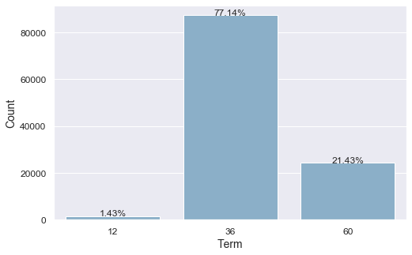

```python
plt.figure(figsize = (8,5))
plt.style.context('fivethirtyeight')

term_categories = [12,36,60]
term_type = pd.api.types.CategoricalDtype(ordered = True, categories = term_categories)
df_loans.Term = clean_data.Term.astype(term_type)

sb.countplot(data = clean_data, x = 'Term', color = base_color)

plt.xticks(size = 12)
plt.xlabel('Term', Size = 14)
plt.yticks( size = 12)
plt.ylabel('Count', Size = 14)

xtick_loc1 ,xtick_lb1= plt.xticks()
for xt_loc1 ,xt_lb1 in zip(xtick_loc1 ,xtick_lb1):
    term_count1 = clean_data.Term.value_counts()[int(xt_lb1.get_text())]
    plt.text(xt_loc1, term_count1,'{:.2f}%'.format(100*term_count1/clean_data.Term.shape[0]), size = 12, ha = 'center');
```

> 36 month re-payment schedules are the most popular with more than 75% of members favoring them over the other two options.

# Borrower APR

```python
clean_data.BorrowerAPR.isna().sum()
```

```
25
```

```python
clean_data.BorrowerAPR.dropna().describe()
```

```
count    113041.000000
mean          0.218980
std           0.080483
min           0.006530
25%           0.156290
50%           0.209840
75%           0.283860
max           0.512290
Name: BorrowerAPR, dtype: float64
```

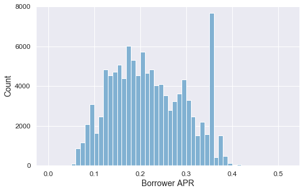

```python
plt.figure(figsize = (8,5))
plt.style.context('fivethirtyeight')

x_bins = np.arange(0, clean_data.BorrowerAPR.dropna().max()+0.01,0.01)
plt.hist(data = clean_data, x = 'BorrowerAPR', bins = x_bins,color = base_color)
plt.xticks(size = 12)
plt.xlabel('Borrower APR', Size = 14)
plt.yticks( size = 12)
plt.ylabel('Count', Size = 14);
```

```python
clean_data[(clean_data.BorrowerAPR >=(0.3)) & (clean_data.BorrowerAPR <(0.4))].BorrowerAPR.value_counts().reset_index(name='count').sort_values(by = 'count',ascending = False)
```

|  | index | count |
| --- | --- | --- |
| 0 | 0.35797 | 3672 |
| 1 | 0.35643 | 1644 |
| 2 | 0.37453 | 1260 |
| 3 | 0.30532 | 902 |
| 4 | 0.35356 | 715 |
| ... | ... | ... |
| 589 | 0.39171 | 1 |
| 588 | 0.30170 | 1 |
| 587 | 0.39951 | 1 |
| 586 | 0.32211 | 1 |
| 922 | 0.34375 | 1 |

923 rows × 2 columns

```python
clean_data[(clean_data.BorrowerAPR >=(0.35797-0.01)) & (clean_data.BorrowerAPR <(0.35797))].BorrowerAPR.shape[0]
```

[output not shown]

```python
0.35797-0.01
```

```
0.34797
```

> One sudden jump is observed in the distribution. It appears that most frequent APR falls roughly between 0.35 and 0.36

### Discuss the distribution(s) of your variable(s) of interest. Were there any unusual points? Did you need to perform any transformations?

- Number of NaN values in entries for Credit Grade is significant. Any investigation and analysis on this feature will be approached with cautioun.
- Out of **113066** entries, **3529** for **`Occupation`** are **NaN** values. And in **40%** of the entries, it is not clear what the occupation is as the value is either 'Other' or 'Professional'. Therefore, `Occupation`will not be used to categorize members.
- **51%** of loans are taken for **Debt Consolidation**. Unfortunately 25% of entries offer un-informative data stating 'Not Available' and 'Other' for Listing Category. It should be decided later on how to handle this issue.
- Due to the number of outliers the distribution for Stated Monthly Income, Debt To Income Ratio and Available Bankcard Credi are significantly right skewed.
- One sudden jump is observed in the distribution. It appears that most frequent APR falls roughly between 0.35 and 0.36

**The data itself didn't need transformation. But scale transformation helped to better see the distribution across the range.**

### Of the features you investigated, were there any unusual distributions? Did you perform any operations on the data to tidy, adjust, or change the form of the data? If so, why did you do this?

**Data Cleaning:**

- Listing Category:
  - Numerical values were replace with their literal values.

**Scale Transformation**

- StatedMonthlyIncome:
  - Data for monthly income is spread over a considerably large range ( 0 – 1.75 million) while 75% of values fell under 7000 . Using the linear scale would show and drastically skewed distribution that would not represent the data accurately. To solve this problem upper bound was set to 30000, and bin size was chosen as such to capture the range of values.
- DebtToIncomeRatio
  - Entries for Debt to Income Ratio fall anywhere between 0%-1000% with increments as low as 0.1%). However, more than 90% of datapoint are under 100%. Therefore, limiting the selection of data point to those with a maximum ratio of 1 presents a better understanding of how the data is distributed. The distribution is right skewed with median at ~0.2 and 75% of values falling under ~0.35.
- AvailableBankcardCredit
  - Given the broad range of entries for available credit (between 0 - 600,000+), log scaling proved to be the best way to ensure the distribution is depicted rather accurately.With Median at \$4000, Most members have less than \\$10000 credit available on their bank card and for 20% of member it stand under \$1000. There are outliers on both higher and lower ends and will be dealt with in later stages.

> *Income Range appeared to be viable feature based on which the data can be categorized and further explored. There are no NaN value and the categories are informative enough. However, categories such as'Not Displayed' does not offer much explanation and the categories $0' and \\$1-24,999. 85% of members fall into 4 categories ( \$25,000-49,999,\\$50,000-74,999, \$75,000-99,999, \\$100,000+). To ensure these for categories have enough share in the loans borrowed, in the next step, the distribution of loans(percentage of total amount) across categories of IncomeRange is explored. If the criteria of being a majory group is met, focus data will be data related to these four categories only.*

# Bivariant Exploration

In previous steps, **Income Range** appeared to be viable feature based on which the data can be categorized and further explored. There are **no NaN value** and the categories are informative enough. However, categories such as'Not Displayed' does not offer much explanation and the categories \$0' and \\$1-24,999.  
**85%** of members fall into **4 categories** ( \$25,000-49,999,\\$50,000-74,999, \$75,000-99,999, \\$100,000+). To ensure these for categories have enough share in the loans borrowed, in the next step, the distribution of loans(percentage of total amount) across categories of `IncomeRange` is explored. If the criteria of being a majory group is met, focus data will be data related to these four categories only.

### Loan Distribution across Categories of Income Range

```python
income_categories = ['$0', '$1-24,999','$25,000-49,999','$50,000-74,999','$75,000-99,999', '$100,000+','Not employed', 'Not displayed']
income_type = pd.api.types.CategoricalDtype(ordered = True, categories = income_categories)
clean_data.IncomeRange = clean_data.IncomeRange.astype(income_type)
```

```python
total_loan_per_income_category = clean_data.groupby('IncomeRange').LoanOriginalAmount.sum().reset_index(name = 'TotalLoan')
total_loan_per_income_category
```

|  | IncomeRange | TotalLoan |
| --- | --- | --- |
| 0 | $0 | 4602188 |
| 1 | $1-24,999 | 30952035 |
| 2 | $25,000-49,999 | 196983612 |
| 3 | $50,000-74,999 | 265945334 |
| 4 | $75,000-99,999 | 173540766 |
| 5 | $100,000+ | 224137555 |
| 6 | Not employed | 3937172 |
| 7 | Not displayed | 40018253 |

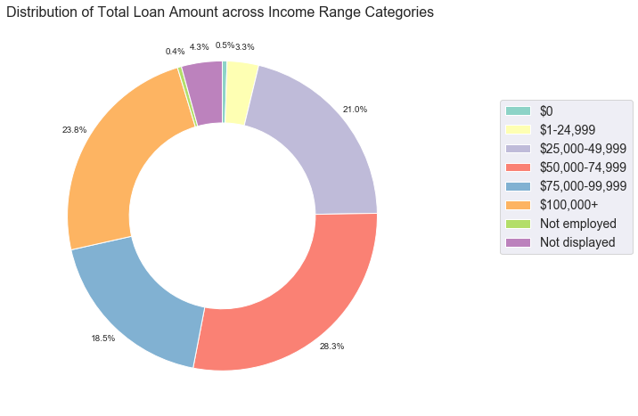

```python
plt.figure(figsize = (8,8))
#plt.style.context('fivethirtyeight')

plt.pie(total_loan_per_income_category.TotalLoan,startangle = 90, counterclock = False, autopct='%1.1f%%',pctdistance=1.1, labeldistance=1.2,wedgeprops = {'width' : 0.4})
plt.legend(labels = total_loan_per_income_category.IncomeRange, loc='center left', bbox_to_anchor=(1.2, 0.6), fontsize = 14);
plt.title('Distribution of Total Loan Amount across Income Range Categories ', size = 16, loc='center');
```

> **Four income range categories** (\$25,000-49,999,\\$50,000-74,999,\$75,000-99,999,\\$100,000+) account for **~92%** of the amount of money borrowed. Therefore,in the steps to come the focus of this analysis will be on these categories only.

## Highly Desired Loan Categories

```python
focus_data = clean_data[((clean_data.IncomeRange == '$25,000-49,999')|(clean_data.IncomeRange =='$50,000-74,999')|(clean_data.IncomeRange == '$75,000-99,999' )|(clean_data.IncomeRange =='$100,000+'))==True]
focus_data.IncomeRange.unique()
```

```
[$25,000-49,999, $50,000-74,999, $100,000+, $75,000-99,999]
Categories (4, object): [$25,000-49,999 < $50,000-74,999 < $75,000-99,999 < $100,000+]
```

```python
focus_data.to_csv('focus_data.csv',index = False)
focus_data = pd.read_csv('focus_data.csv')
```

```python
fd_income_range_order = ['$25,000-49,999', '$50,000-74,999', '$75,000-99,999','$100,000+']
fd_income_range_type = pd.api.types.CategoricalDtype(ordered = True, categories = fd_income_range_order)
focus_data.IncomeRange = focus_data.IncomeRange.astype(fd_income_range_type)
```

```python
focus_data.CreditGrade = focus_data.CreditGrade.astype(cg_ordered_type)
```

```python
temp =focus_data.groupby('IncomeRange').ListingCategory.value_counts().reset_index(name = 'Count').pivot(index = 'ListingCategory',columns = 'IncomeRange', values ='Count')
temp.sort_values(['$25,000-49,999','$50,000-74,999','$75,000-99,999','$100,000+'],ascending = [False,False,False,False]).head(5)
```

| IncomeRange ListingCategory | $25,000-49,999 | $50,000-74,999 | $75,000-99,999 | $100,000+ |
| --- | --- | --- | --- | --- |
| Debt Consolidation | 16657 | 17888 | 9928 | 9983 |
| Not Available | 3541 | 2293 | 1024 | 907 |
| Other | 3417 | 2857 | 1549 | 1430 |
| Business | 2036 | 1885 | 1130 | 1373 |
| Home Improvement | 1873 | 2139 | 1323 | 1704 |

> **Top 5 of desired loans** for each Income Range categories are as seen above. This information will be used for prepation of data that will be used in next steps of bivariant exploration. Given the fact that 'other' and 'Not Available' are not very informative. They will not be considered

```python
desired_loans = focus_data[((focus_data.ListingCategory == 'Debt Consolidation')|(focus_data.ListingCategory =='Business')|(focus_data.ListingCategory == 'Home Improvement'))==True]
```

## Repayment Term, Credit Grade and Highly Desired Loan across Income Categories

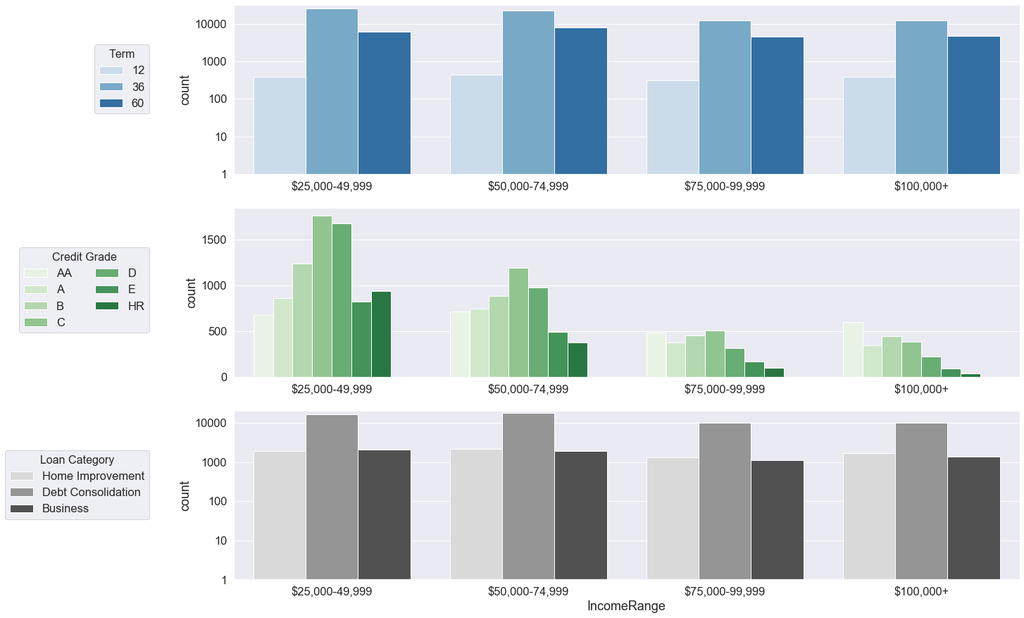

```python
fig, (ax1,ax2,ax3) = plt.subplots(3,1, figsize = (20,15))

#Term distribution for Incom category
sb.countplot(data = focus_data, x = 'IncomeRange', hue = 'Term', palette = 'Blues', ax = ax1)

ax1.set_yscale('log')
ax1.set_yticks([1,10,100,1000,10000],[1,10,100,1000,10000])
ax1.get_yaxis().set_major_formatter(matplotlib.ticker.ScalarFormatter())
ax1.legend(bbox_to_anchor=(-0.1, 0.8), loc='best', ncol=1, title = 'Term')
ax1.get_legend().get_title().set_fontsize('16')
ax1.set_xlabel('')

sb.countplot(data = focus_data, x = 'IncomeRange', hue = 'CreditGrade',palette = 'Greens', ax = ax2)
ax2.legend(['AA' , 'A' , 'B' , 'C' , 'D' , 'E' , 'HR'], bbox_to_anchor=(-0.1,0.8), loc='best', ncol=2, title = 'Credit Grade')
ax2.get_legend().get_title().set_fontsize('16')
ax2.set_xlabel('')

sb.countplot(data = desired_loans, x = 'IncomeRange' ,hue = 'ListingCategory',palette = 'Greys', ax = ax3)
ax3.legend( bbox_to_anchor=(-0.1, 0.8), loc='best', ncol=1, title = 'Loan Category')
ax3.get_legend().get_title().set_fontsize('16')
ax3.set_yscale('log')
ax3.set_yticks([1,10,100,1000,10000],[1,10,100,1000,10000])
ax3.get_yaxis().set_major_formatter(matplotlib.ticker.ScalarFormatter())
```

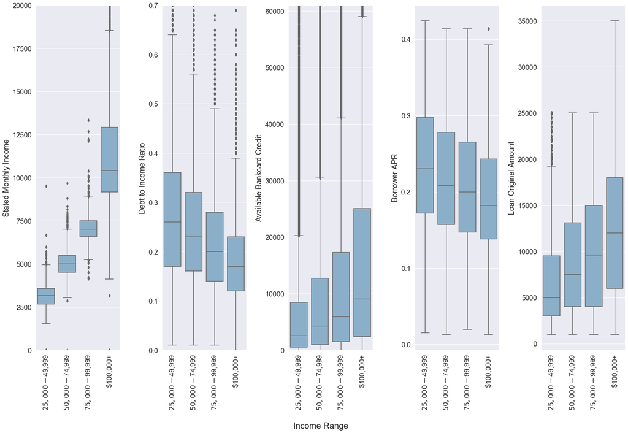

```python
fig, (ax1,ax2,ax3, ax4, ax5) = plt.subplots(1,5, figsize = (25,15))
fig.text(0.5, -0.05, 'Income Range',va = 'bottom',ha='center',size = 20)
plt.subplots_adjust(wspace=0.5, hspace=0.2)

xticks = ['$25,000-$49,999','$50,000-$74,999','$75,000-$99,999','$100,000+']
sb.boxplot(data = focus_data, x = 'IncomeRange', y='StatedMonthlyIncome', color = base_color,ax = ax1)
ax1.set_ylabel('Stated Monthly Income',size = 18)
ax1.set_ylim(0,20000)
ax1.set_xticklabels(labels=xticks,rotation = '90')
ax1.set_xlabel('')

sb.boxplot(data = focus_data, x = 'IncomeRange', y='DebtToIncomeRatio', color = base_color,ax = ax2)
ax2.set_ylabel('Debt to Income Ratio',size = 18)
ax2.set_ylim(0,0.7)
ax2.set_xticklabels(labels = xticks, rotation = '90')
ax2.set_xlabel('')

sb.boxplot(data = focus_data, x = 'IncomeRange', y='AvailableBankcardCredit', color = base_color,ax = ax3)
ax3.set_ylabel('Available Bankcard Credit',size = 18)
ax3.set_ylim(0,61000)
ax3.set_xticklabels(labels = xticks, rotation = '90')
ax3.set_xlabel('')

sb.boxplot(data = focus_data, x = 'IncomeRange', y='BorrowerAPR',color = base_color, ax = ax4)
ax4.set_ylabel('Borrower APR',size = 18)
ax4.set_xticklabels(labels = xticks, rotation = '90')
ax4.set_xlabel('')

sb.boxplot(data = focus_data, x = 'IncomeRange', y='LoanOriginalAmount', color = base_color,ax = ax5)
ax5.set_ylabel('Loan Original Amount',size = 18);
ax5.set_xticklabels(labels = xticks, rotation = '90')
ax5.set_xlabel('');
```

## Relationships among Features of Interest

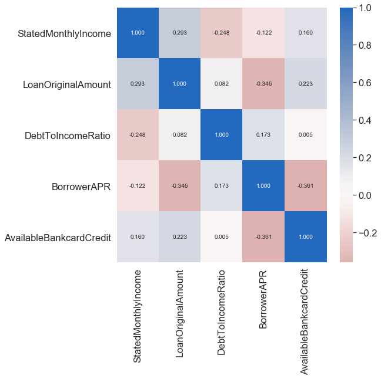

```python
plt.figure(figsize = (8,8))
sb.heatmap(sample[['StatedMonthlyIncome','LoanOriginalAmount','DebtToIncomeRatio','BorrowerAPR','AvailableBankcardCredit']].corr(), annot = True, fmt = '.3f',
           cmap = 'vlag_r', center = 0);
```

> Overall the relationships either positive or negative do not appear to be strong. But given the correlation coeficients, the following is observed in the data:
> - members with higher monthly incom and more credit available on their bank card, enjoy better APR and opt for larger loans.
> - As Debt to Income Ratio decreases APR improves. While the available credit on bank card does not make a strong impact on Debt to Income Ratio, it is observed that higher monthly income lowers the ratio.
> - Available credit contributes most to improving APR.

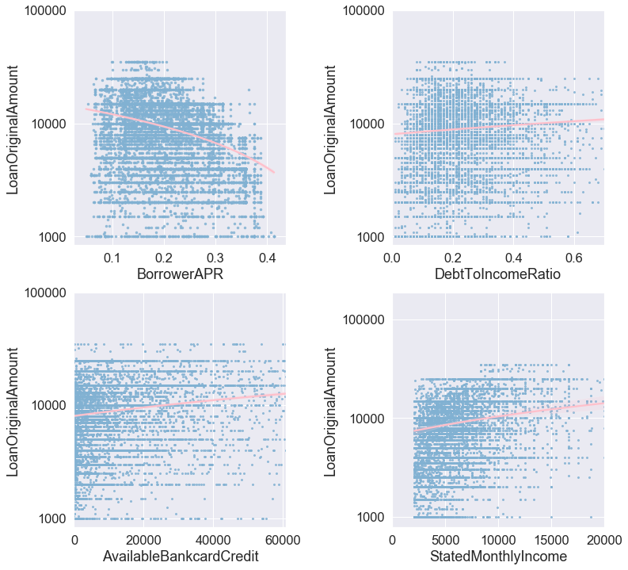

```python
plt.figure(figsize = (12,12))
plt.subplots_adjust(wspace=0.5, hspace=0.2)

plt.subplot(221)
sb.regplot(data = sample, x = 'BorrowerAPR', y = 'LoanOriginalAmount',line_kws={"color": "pink"}, color = base_color,scatter_kws={'s':6})
plt.yscale('log')
plt.yticks([1000,10000,100000],[1000,10000,100000])

plt.subplot(222)
sb.regplot(data = sample, x = 'DebtToIncomeRatio', y = 'LoanOriginalAmount',line_kws={"color": "pink"},color = base_color,scatter_kws={'s':4})
plt.yscale('log')
plt.yticks([1000,10000,100000],[1000,10000,100000])
plt.xlim(0,0.7)

plt.subplot(223)
sb.regplot(data = sample, x = 'AvailableBankcardCredit', y = 'LoanOriginalAmount',color = base_color,line_kws={"color": "pink"},scatter_kws={'s':4})
plt.yscale('log')
plt.yticks([1000,10000,100000],[1000,10000,100000])
plt.xlim(0,61000)

plt.subplot(224)
sb.regplot(data = sample, x = 'StatedMonthlyIncome', y = 'LoanOriginalAmount',color = base_color,line_kws={"color": "pink"},scatter_kws={'s':4})
plt.yscale('log')
plt.yticks([1000,10000,100000],[1000,10000,100000])
plt.xlim(0,20000);
```

> Scatter plot results are in line with the correlation coeficients observed in the previous step

## Deciding Factors in Better/Worse Borrower APR

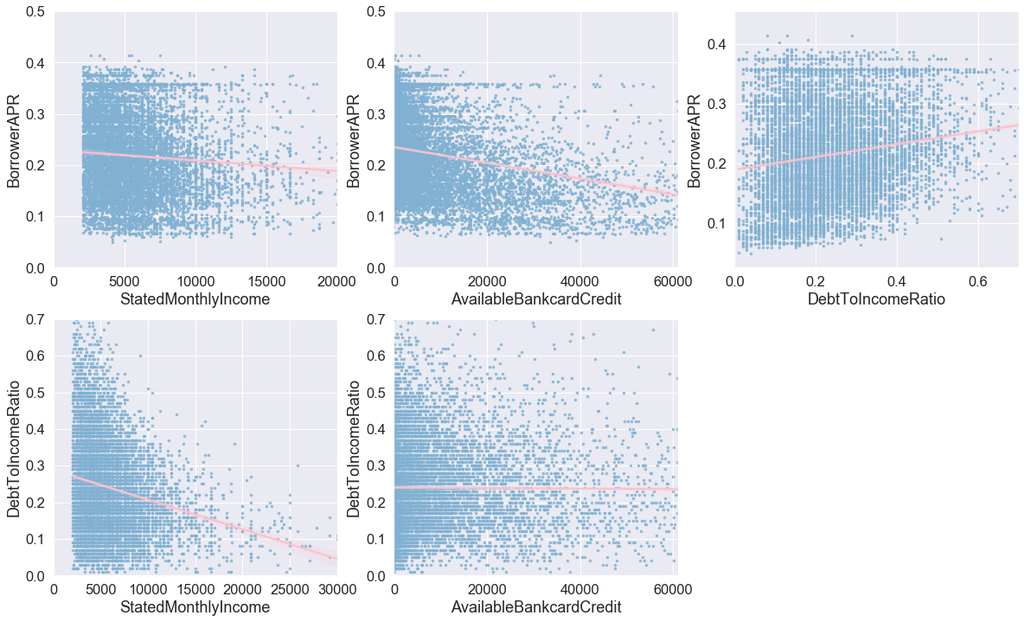

```python
plt.figure(figsize = (20,12))
plt.subplot(231)
sb.regplot(data = sample, y = 'BorrowerAPR', x = 'StatedMonthlyIncome',line_kws={"color": "pink"},color = base_color,scatter_kws={'s':6})
plt.xlim(0,20000)
plt.ylim(0,0.5)

plt.subplot(232)
sb.regplot(data = sample, y = 'BorrowerAPR', x = 'AvailableBankcardCredit',line_kws={"color": "pink"},color = base_color,scatter_kws={'s':6})
plt.xlim(0,61000)
plt.ylim(0,0.5)
plt.subplot(233)
sb.regplot(data = sample, y = 'BorrowerAPR', x = 'DebtToIncomeRatio',line_kws={"color": "pink"},color = base_color,scatter_kws={'s':6})
plt.xlim(0,0.7)

plt.subplot(234)
sb.regplot(data = sample,y = 'DebtToIncomeRatio', x= 'StatedMonthlyIncome', line_kws={"color": "pink"},color = base_color,scatter_kws={'s':6})
plt.ylim(0,0.7)
plt.xlim(0,30000)

plt.subplot(235)
sb.regplot(data = sample,y = 'DebtToIncomeRatio', x= 'AvailableBankcardCredit', line_kws={"color": "pink"},color = base_color,scatter_kws={'s':6})
plt.ylim(0,0.7)
plt.xlim(0,61000);
```

> Scatter plots support the conclusions made from correlation coeficients. Biggest impacts on APR are caused by available credit(improves) and debt to income ratio(worsens).

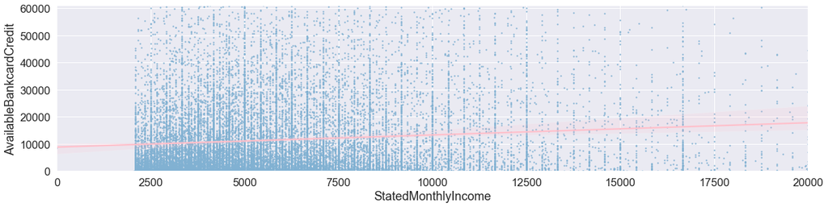

```python
sample2 = focus_data.sample(30000)
plt.figure(figsize = (20,10))
plt.subplot(211)
sb.regplot(data = sample2,x = 'StatedMonthlyIncome', y= 'AvailableBankcardCredit',x_jitter=0.04, line_kws={"color": "pink"},color = base_color,scatter_kws={'s':2})
plt.ylim(0,61000)
plt.xlim(0,20000);
```

### Talk about some of the relationships you observed in this part of the investigation. How did the feature(s) of interest vary with other features in the dataset?

**Four income range categories (\$25,000-49,999,\\$50,000-74,999,\$75,000-99,999,\\$100,000+) account for ~92%of the amount of money borrowed. Therefore,focus of analysis was on these categories only.**

**Scatter plots further supported the observations.**

# Multi-variant Exploration

## Average Loan Amount of Income Categories across Different Terms, Credit Grades and Desired Loan Categories

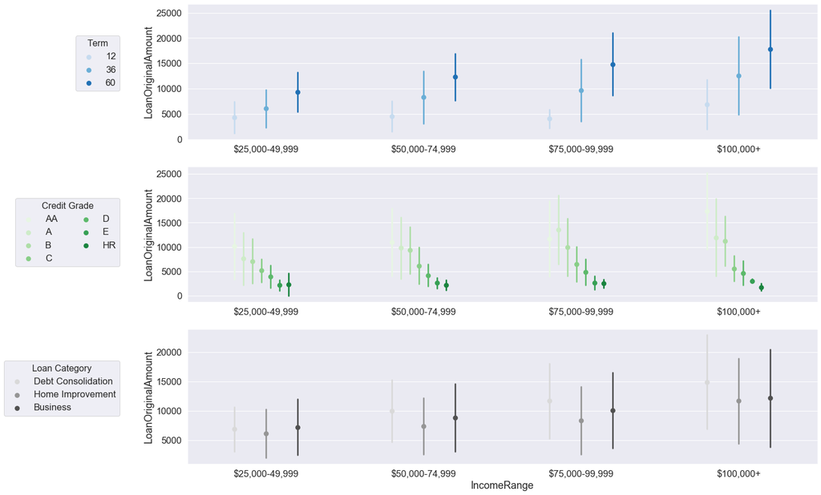

```python
fig, (ax1,ax2,ax3) = plt.subplots(3,1, figsize = (20,15))

sb.pointplot(data = sample3, x = 'IncomeRange', y = 'LoanOriginalAmount',hue = 'Term',
           palette = 'Blues', linestyles = '', dodge = 0.4, ci='sd',ax = ax1)
ax1.legend(bbox_to_anchor=(-0.1, 0.8), loc='best', ncol=1, title = 'Term')
ax1.get_legend().get_title().set_fontsize('16')
ax1.set_xlabel('')


sb.pointplot(data = sample3, x = 'IncomeRange', y = 'LoanOriginalAmount',hue = 'CreditGrade',
           palette = 'Greens', linestyles = '', dodge = 0.4, ci='sd',ax = ax2)
leg_handles = ax2.get_legend_handles_labels()[0]
ax2.legend(leg_handles,['AA' , 'A' , 'B' , 'C' , 'D' , 'E' , 'HR'],bbox_to_anchor=(-0.1, 0.8), loc='best', ncol=2, title = 'Credit Grade')
ax2.get_legend().get_title().set_fontsize('16')
ax2.set_xlabel('')

sample3 = desired_loans.sample(10000)
sb.pointplot(data = sample3, x = 'IncomeRange', y = 'LoanOriginalAmount',hue = 'ListingCategory',
           palette = 'Greys', linestyles = '', dodge = 0.4, ci='sd',ax = ax3)
ax3.legend(bbox_to_anchor=(-0.1, 0.8), loc='best', ncol=1, title = 'Loan Category')
ax3.get_legend().get_title().set_fontsize('16')
```

- Although most members, as observed earliear, pay off their loans in 36months. It appears that , across all income range categories, 60month term is favored for repayment of higher loans.
- Average amount of loans borrowed is higher for members with better credit rate
- for the 3 highest income range category on average loans taken for debt consolidation is the largest while for members in 25000-49,999 income range larger average loan is borrowed for business.

## Impact of Debt to Income Ratio, Monthly Income and Available Credit on APR across Income Range and Credit Grade

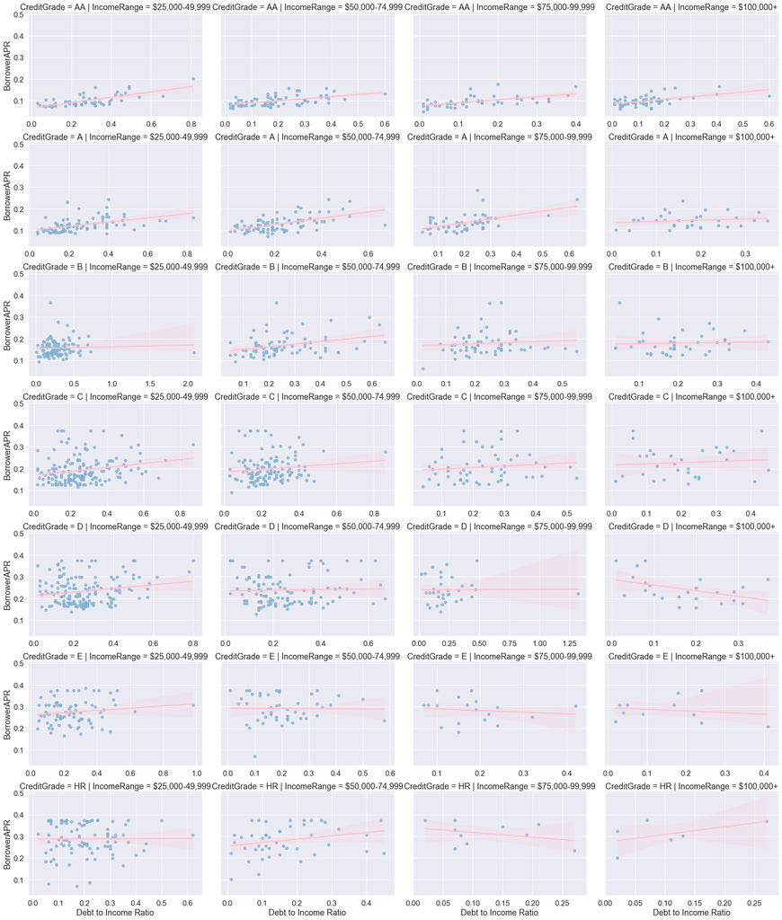

```python
g=sb.FacetGrid(data=sample, aspect=1.5, height=4, col='IncomeRange', row ='CreditGrade',sharex=False)
g.map(sb.regplot, 'DebtToIncomeRatio','BorrowerAPR',  color = base_color,line_kws={'color':'pink'});
for i in range(4):
    g.fig.delaxes(g.axes[7,i])
    g.axes[6,i].set_xlabel('Debt to Income Ratio');
```

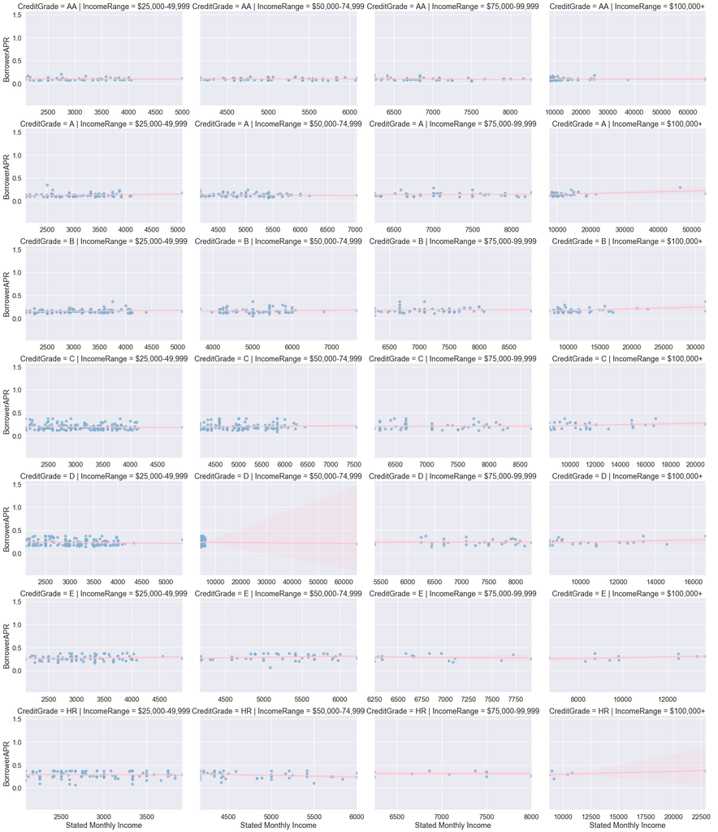

```python
g=sb.FacetGrid(data=sample, aspect=1.5, height=4, col='IncomeRange', row ='CreditGrade',sharex=False)
g.map(sb.regplot, 'StatedMonthlyIncome','BorrowerAPR',  color = base_color,line_kws={'color':'pink'});
g.add_legend()
for i in range(4):
    g.fig.delaxes(g.axes[7,i])
    g.axes[6,i].set_xlabel('Stated Monthly Income');
```

```
''
```

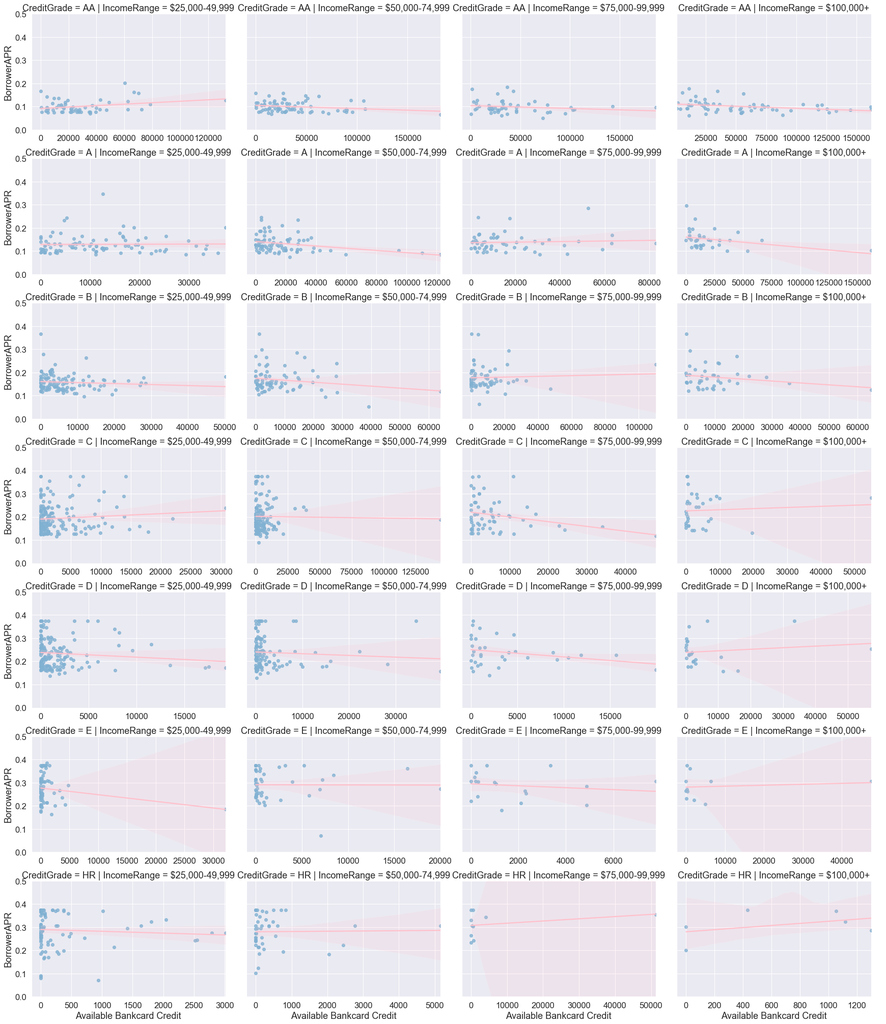

```python
g=sb.FacetGrid(data=sample, aspect=1.5, height=4, col='IncomeRange', row ='CreditGrade',sharex=False)
g.map(sb.regplot, 'AvailableBankcardCredit','BorrowerAPR',  color = base_color,line_kws={'color':'pink'});
g.add_legend()
g.set(ylim = (0,0.5))
for i in range(4):
    g.fig.delaxes(g.axes[7,i])
    g.axes[6,i].set_xlabel('Available Bankcard Credit');
```

What is observed in scatter plots is very much in line with earlier objervations. However, there are cases that data has behaved out of character. Such discrepencies should be attributed to the fact that the data available for Credit Grade is extremely limited. Therefore random entries and existance of outlier can lead to misleading representation of relationships

### Talk about some of the relationships you observed in this part of the investigation. Were there features that strengthened each other in terms of looking at your feature(s) of interest?

- Although most members, as observed earliear, pay off their loans in 36months. It appears that , across all income range categories, 60month term is favored for repayment of higher loans.
- Average amount of loans borrowed is higher for members with better credit rate
- for the 3 highest income range category on average loans taken for debt consolidation is the largest while for members in 25000-49,999 income range larger average loan is borrowed for business.

> **What is observed in scatter plots is very much in line with earlier objervations. However, there are cases that data has behaved out of character. Such discrepencies should be attributed to the fact that the data available for Credit Grade is extremely limited. Therefore random entries and existance of outlier can lead to misleading representation of relationships**

## Limitation

**Listing Category** A significant portion of loans are listed under other or Not available. Therefore the analysis falls short of accurately make a statement on what the loans are borrowed for.